# Reading the ANES Cumulative File

Seventy-six years of survey answers, and three columns that run backwards

Democracy’s Data

Last updated September 13, 2026 at 10:53a EDT

The American National Election Studies has asked Americans about politics in every presidential election since 1948, and in most midterms since. The cumulative file gathers seventy-six years of it into one table: 73,745 interviews, 1,030 columns, 163 megabytes of numbers. It is the longest continuous record of American political behaviour that exists.

It is the file behind this book’s Public Opinion cluster, and that cluster measures the kind of thing no election ever grades. A poll about a vote is eventually scored against a real result. A question about party identification, ideology, abortion, or trust never is, because there is no true national figure to score it against. When nothing can grade the answer, the method is the whole credential: the sampling, the wording, and the codebook. This chapter is about learning to read all three.

It is also a file in which **three of the columns this chapter uses run in the opposite direction from the one you would assume**, and nothing in the data says so. Two of the three fooled the person who built this chapter. The resulting figures were not broken — they were readable, plausible, and wrong, which is the only kind of error worth writing a chapter about.

## Where the data comes from, and what it is for

ANES is run by the University of Michigan and Stanford University under a National Science Foundation grant. Its purpose is not to report the news and never has been: it exists so that the same question, asked in the same words, can be compared across decades. That single design decision is what makes the cumulative file possible and what makes it strange.

**Who is in it, and how they got there.** Each study interviews a national probability sample of voting-age adults, a sample drawn so that every kind of person has a known chance of being picked. Most respondents are interviewed twice, once before the election and once after. Each study draws a fresh sample — a **cross-section**, a snapshot of different people each time — rather than a **panel** that follows the same people for years, so the file can show how the country changed but not how any one person did. Nobody is obliged to answer, and most people approached decline. The cumulative file stacks every study since 1948 into one table, one row per interview, so a 22-year-old questioned about Truman sits a few thousand rows above one questioned about Trump.

**Who it was made for.** Political scientists asking whether the country has changed. Totals like vote counts and party divisions tell you what a country did; ANES is one of very few sources recording what individual people *said* about it, and the only one doing so since Truman. The whole investment in long interviews, frozen wording and careful samples buys comparability over time rather than speed or size.

**What it costs to get.** Nothing in money, and one deliberate inconvenience. The file is requested, not handed over. ANES asks that everyone take it from ANES rather than pass copies around: a reader registers for a free account at electionstudies.org, finds the Time Series Cumulative Data File in the site’s data center, and downloads it in a browser. That is the one route, and it is why the 163 MB file is not included with this chapter. The small tables in this chapter’s folder, cut from it, are.

**What has already been done to it.** A great deal, and this is the important part. The cumulative file is not a pile of surveys; it is a *reconciliation*. ANES staff recoded seventy-six years of differently worded, differently ordered, differently scaled questions so that one column — each is labelled with a VCF number, the file’s own name for a question, `VCF0301` for party identification and so on — means one thing throughout. The file is comparable across time only because people made it so, case by case.

The codebook — the document that says what every column, and every number in it, means — is the record of those decisions, and ANES states plainly that the data cannot be used with any codebook but its own. That is not a formality. It is the whole warranty.

## What arrives, and why it needs the codebook

The file is published as one CSV plus two codebook volumes, re-released after each new study folds in; the version read here is dated 5 February 2026. A question earns a column only if it was asked in three or more studies. Each column keeps its VCF number across every release, so a brief written against one release still runs against the next. Here are five random rows — not the first five, because the file is ordered by study year and the first five are all interviews from 1948.

```
ANES Time Series Cumulative Data File, 20260205 CSV distribution
73,745 rows x 1,030 columns

The first 14 of 1,030 column names, exactly as they arrive:
Version VCF0004 VCF0006 VCF0006a VCF0009x VCF0010x VCF0011x
VCF0009y VCF0010y VCF0011y VCF0009z VCF0010z VCF0011z VCF9999

Five random rows, the columns this chapter reads, values untouched:

VCF0004  VCF0301  VCF0310  VCF0050a  VCF0050b  VCF0806  VCF0838  VCF9039  VCF9040  VCF9041  VCF9042  VCF0009z
1970  4  3  NA   1  4  NA  NA  NA  NA  NA  1.0000
1972  6  3   3  NA  0  NA  NA  NA  NA  NA  1.0000
1984  3  2   3   3  9   2  NA  NA  NA  NA  1.0000
1994  2  2  NA   3  2   2   2   3   2   2  0.9981
2016  7  3   3   3  7   2   2   1   2   2  1.5380

Every -1, 0 and 9 above is a code, not a measurement.
The codebook is the only way to know which is which.
```

Every value above is a number, and only some of them are measurements. On this evidence alone you cannot tell which is which, and no amount of staring at the file will tell you. That is what the codebook is for.

Take one column. `VCF0806` asks where the respondent stands between a government insurance plan and a private one, on a scale of one to seven. The column also contains `-1`, `0` and `9`. Those are not positions on the scale. They are **missing-value codes**, numbers that stand for the absence of an answer: *inapplicable*, *no post-election interview*, and *don’t know*. Together they are **20.80% of every answer in the column** — 10,063 of 48,381.

Now average the column four ways.

| What was removed | Mean | Answers used | Distance from correct |
| --- | --- | --- | --- |
| Nothing removed, the file as it arrives | 3.966 | 48,381 | +0.137 |
| Only 9 (don’t know) removed | 3.380 | 43,337 | -0.449 |
| Only 0 and -1 (inapplicable) removed | 4.431 | 43,362 | +0.602 |
| Every non-scale code removed | 3.829 | 38,318 | — |

**The first row is the answer you get by doing nothing, and the middle two explain why it looks acceptable.** Doing nothing gives 3.966, and the correct answer is 3.829. That is off by only 0.137 on a seven-point scale, which is small enough to survive any sanity check you might apply to it.

It is small for a reason that should frighten you. The `9`s are larger than the largest real answer, so they drag the mean up. The `0`s and `-1`s are smaller than the smallest, so they drag it down. There are 5,044 of the first and 5,019 of the second, and **the two errors very nearly cancel**. Clean half the problem and the cancellation breaks: remove only the don’t-knows and you get 3.380; remove only the inapplicables and you get 4.431. Both are three to four times further from the truth than leaving the column entirely alone.

## Three columns that run backwards

The worked example is one claim, taken from the codebook to a figure: *the parties have pulled apart on racial attitudes, and one of them did most of the moving.* Three columns stand between the file and that sentence, and every one of them points the opposite way from the way you would guess.

The first is the interviewer’s rating of how politically informed the respondent seemed, the raw material of the field’s **political awareness** scale, a measure of how much a person knows and notices about politics. John Zaller showed that awareness governs how far a person’s opinions follow the leaders of their own party, and the scale is the axis of his charts.[^1] No respondent has ever been asked how aware they are; there is no such question and no such column. Awareness is *built*, usually from this rating and from the respondent’s own account of how closely they followed the campaign. Two defensible builds from the same file:

| How it was built | Respondents | Years | Distinct levels |
| --- | --- | --- | --- |
| Interviewer rating only (VCF0050a, falling back to VCF0050b) | 41,635 | 1966–2016 | 5 |
| Interviewer rating plus campaign interest (VCF0310) | 38,773 | 1966–2016 | 9 |

Neither is more correct than the other. They cover different people, they have different resolution, and a reader shown only a finished figure has no way to know which was used or that a choice existed. And the rating itself is coded like this, in the codebook and nowhere in the data:

| Variable | Code | What the code means |
| --- | --- | --- |
| VCF0050a — respondent level of political info | 1 | Very high |
|  | 2 | Fairly high |
|  | 3 | Average |
|  | 4 | Fairly low |
|  | 5 | Very low |

**One is the most informed respondent, not the least.** The scale descends. Zaller’s classic result is that the gap between ordinary Democrats and Republicans on an issue is *widest* among the most aware, because they are the people who have heard what their party’s leaders say and taken the cue. Read the rating the intuitive way, one as least informed and five as most, and the file appears to say the opposite: the party gap *shrinks* as awareness rises. That reads as a comfortable finding about information moderating partisanship, rather than as a coding error.

Read the right way round, the file shows what the literature shows. On government health insurance, the gap between Republicans and Democrats is 0.79 points among the least aware and 2.04 among the most aware. On abortion it is 0.06 at the bottom (indistinguishable from nothing) and 0.62 at the top. A party gap that grows with attention is not a fact about what ordinary Democrats and Republicans are like; it is a record of how far down from the political elite — the officeholders and commentators who disagree first — the disagreement has travelled.

The second and third backwards columns sit in the **racial resentment** battery — a battery is a set of questions asked together — four statements about Black Americans, effort and history that respondents agree or disagree with, asked since 1986 and the standard survey measure of the concept since Kinder and Sanders built it.[^2] All four use the same response scale, one for agree strongly through five for disagree strongly, and two of them mean the opposite of the other two:

| Variable | Item | Agreeing means |
| --- | --- | --- |
| VCF9039 | Conditions make it difficult for blacks to succeed | less resentment |
| VCF9040 | Blacks should not have special favors to succeed | more resentment |
| VCF9041 | Blacks must try harder to succeed | more resentment |
| VCF9042 | Blacks gotten less than they deserve | less resentment |

Reversing means flipping the scale on two of the items — five becomes one, four becomes two — so that on all four a higher number means more resentment. Skip it and the directions cancel. Take the most resentful respondent possible: agrees strongly, code 1, that Black Americans should not get special favours, and disagrees strongly, code 5, that conditions make it difficult for them to succeed. Unreversed, those two answers average to 3, the exact middle — and so do the opposite answers from the least resentful respondent possible. Average the four items that way for everyone and every party lands within five hundredths of every other, in every year, for thirty-eight years. That would be a spectacular finding: *no partisan difference in racial attitudes, ever*. It is arithmetic on mixed-direction items, nothing more. Reversed properly, the same four questions give this.

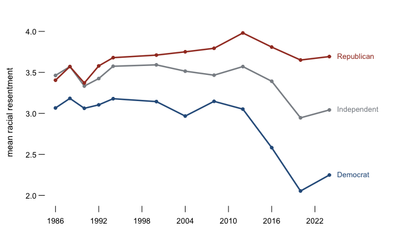

**Figure 1. Mean racial resentment by party identification, 1986–2024; higher is more resentful.** The chart is three lines on a time axis because the claim is a claim about change: a gap that widened, and which side moved. A single-year snapshot could show the gap but not the movement, and only lines running side by side let you see that one stays roughly level while the other falls. Hovering a year gives all three levels and the Republican-minus-Democrat gap.

The gap between Republicans and Democrats was 0.34 points in 1986 and 1.44 in 2024. It more than quadrupled. And the movement is asymmetric: Republicans end close to where they started, while Democrats fall by 0.82 points. The parties did not walk away from each other. One of them walked.

That is the whole method of the Public Opinion cluster in miniature. Every brief in it pulls one question from a file like this one, checks the codes against a codebook, decides what to do with the non-answers, and only then draws the trend.

## What this data cannot tell you

**Anything asked fewer than three times.** The three-study rule that builds the file also bounds it: anything asked once or twice is not here, and that includes most questions about anything new. The file is excellent on what has been asked for decades and silent on everything else, and that silence looks exactly like the thing not mattering.

**Anything outside a variable’s own years.** Coverage is uneven, and the gaps are not where you would guess.

| Variable | Question | Years | Studies | Answers |
| --- | --- | --- | --- | --- |
| VCF0009z | Sample weight | 1948–2024 | 33 | 73,745 |
| VCF0301 | Party identification, 7 point | 1952–2024 | 32 | 73,083 |
| VCF0310 | Interest in the campaign | 1952–2024 | 30 | 70,124 |
| VCF0050b | Interviewer rating of political information (b) | 1966–2016 | 20 | 37,983 |
| VCF0050a | Interviewer rating of political information (a) | 1968–2016 | 14 | 29,773 |
| VCF0806 | Government health insurance, 7 point | 1970–2024 | 16 | 48,381 |
| VCF0838 | Abortion, 4 point | 1980–2024 | 17 | 48,086 |
| VCF9039 | Conditions make it difficult for blacks to succeed | 1986–2024 | 12 | 39,802 |
| VCF9040 | Blacks should not have special favors to succeed | 1986–2024 | 13 | 41,083 |
| VCF9041 | Blacks must try harder to succeed | 1986–2024 | 12 | 39,802 |
| VCF9042 | Blacks gotten less than they deserve | 1986–2024 | 13 | 41,083 |

**That a question meant the same thing throughout.** Wording drifts, and ANES documents the changes, because a question asked identically in 1972 and 2024 may still not mean the same thing to the person hearing it. The file gives you comparability; it cannot give you equivalence.

**Levels, as measured here.** Nothing in this chapter is weighted — no answer is counted more than another to make the sample’s mix of ages, races and regions match the census — so `VCF0009z`, the weight ANES supplies for that purpose, sits in the file unused, and every number above describes the people ANES interviewed rather than the country. For gaps between groups inside the same survey that matters less than it would for a level, but it is a choice, and you should know it was made. The awareness figures also pool every study year, so they show the shape of the pattern rather than its history. And racial resentment is a measure with a large critical literature attached. This chapter shows what happens when two of its four items point the wrong way, which is a claim about arithmetic, not about the concept.

## What you should have learned

- The cumulative file is a reconciliation, not a pile of surveys: 73,745 interviews recoded so one column means one thing across seventy-six years, and the codebook is the only warranty that it does.
- Non-answer codes live inside the data columns. In `VCF0806` they are 20.80% of all values, and half-cleaning them is worse than not cleaning at all — 3.380 and 4.431 both sit further from the correct 3.829 than the naive 3.966 does.
- The direction of a scale is not a property of the data. It is a fact kept in the codebook, and a backwards read produces figures that are plausible rather than broken.
- Public-opinion measures are never graded by an election, so the method is the credential. Read this way, the file shows the party gap on racial resentment growing from 0.34 points in 1986 to 1.44 in 2024, with Democrats doing most of the moving.
- Coverage bounds every question: only 9 of the 11 variables this chapter touches reach 2024.

## Where this data appears in this book

Each brief in the Public Opinion cluster pulls one question from the ANES cumulative file or a file built the same way, and reads it with exactly the discipline this chapter teaches.

- Party Identification and the Leaner Problem: one coding decision about a follow-up question, and the most repeated number in American politics moves by a factor of five.
- Ideological Self-Placement in ANES: a fifth of Americans take the exit the question offers them, and what dropping them does.
- Abortion Opinion, 1980–2024: four printed options and the fifty years of shares they produce.
- What a Question About the Economy Measures: one economy, rated by two parties, changing sign whenever the White House does.
- Nobody Started Liking Their Own Side More: forty-six years of feeling thermometers, and which half of the gap moved.
- The Gender Gap Is a Subtraction: the one number everybody quotes and the two numbers underneath it, from the GSS cumulative file.
- Confidence in Institutions, GSS 1973–2024: fifty-one years of one question, and the summary that does not survive it.
- The Perception Gap: what each party thinks the other is made of, and how wrong that is.

## Sources

**Data**

- American National Election Studies. *ANES Time Series Cumulative Data File (1948–2024)*, version of 5 February 2026. Ann Arbor, MI and Palo Alto, CA: University of Michigan and Stanford University. https://electionstudies.org/data-center/anes-time-series-cumulative-data-file/
- ANES. *Time Series Cumulative Data File Codebook* and *Appendices*, same release. Every variable coding quoted in this chapter is read from the codebook, including the ones that run backwards.

**Academic literature**

- Zaller, John R. (1992). *The Nature and Origins of Mass Opinion.* Cambridge University Press. The awareness scale, and the patterns it reveals, are his. https://doi.org/10.1017/CBO9780511818691
- Tesler, Michael (2016). *Post-Racial or Most-Racial? Race and Politics in the Obama Era.* University of Chicago Press. Figure 1 is a much-simplified version of a relationship he documents at length. https://press.uchicago.edu/ucp/books/book/chicago/P/bo22961444.html
- Kinder, Donald R. and Lynn M. Sanders (1996). *Divided by Color: Racial Politics and Democratic Ideals.* University of Chicago Press. The racial resentment battery is theirs. https://press.uchicago.edu/ucp/books/book/chicago/D/bo3620441.html
- Converse, Philip E. (1964). “The Nature of Belief Systems in Mass Publics,” in David E. Apter, ed., *Ideology and Discontent.* Free Press.

**The data itself**

Every figure above is drawn from these tables. They are plain CSV, they open in a spreadsheet, and they are yours to take further.

`awareness.csv`, `codes.csv`, `coverage.csv`, `resentment.csv`, `zaller.csv`

**Your turn**

None of these is answered above, and every one can be answered from the tables you just opened.

- `codes.csv` shows the same quantity computed with and without the non-answer codes removed, with an `error` on each. Work out how big the mistake is. Would you have noticed it in a published table?
- `coverage.csv` says which years each variable actually spans. Find a variable you would want for a fifty-year trend and check whether it runs the whole way. What breaks if it does not?
- `zaller.csv` splits each item by party and by awareness. Read across the awareness levels within one party. Do better-informed partisans agree more with their own side, or less?
- `resentment.csv` runs one measure by party across the years. Find where the two parties diverge. Then check `coverage.csv` to see whether the question was even asked the same way throughout.

Why this data cannot be fetched again

```
The file behind this chapter comes from a source no script can download
for you, and it cannot be passed along to you either.

WHY NOT. The chapter is built on the American National Election
Studies Time Series Cumulative Data File, 1948-2024, in the version
of 5 February 2026 — every ANES election survey since 1948, recoded
by staff so that the same variable number asks the same question
across seventy years of studies. Its download page,
https://electionstudies.org/data-center/anes-time-series-cumulative-data-file/
answers 403 to a script and 200 to a browser: the wall judges the
client, not the request, so no assistant can download the file
unattended. Behind the wall sit a free registration and a 22 MB zip
holding a 163 MB CSV. ANES asks that everyone take the file from
ANES, so it is not redistributed here.

WHAT EXISTS INSTEAD. Register yourself — it is free and takes a few
minutes — and download the CSV distribution in a browser, along with
the two codebook PDFs that ship beside it. From that moment on an
assistant can do everything: read the file, look codes up in the
codebook, redo every number. The only step no assistant can do for
you is the download.

WHAT YOU CAN STILL CHECK. Once you hold the file, these numbers say
whether it is the same object:
- 73,745 rows and 1,030 columns in the CSV
- the government health insurance scale, VCF0806, carries 48,381
  non-empty values; its mean is 3.966 as the column arrives and
  3.829 once every code that is not a real answer is removed
- both interviewer ratings of political information, VCF0050a and
  VCF0050b, stop in 2016, eight years before the file ends
```

[^1]: John R. Zaller, *The Nature and Origins of Mass Opinion* (Cambridge: Cambridge University Press, 1992), https://doi.org/10.1017/CBO9780511818691.
[^2]: Donald R. Kinder and Lynn M. Sanders, *Divided by Color: Racial Politics and Democratic Ideals* (Chicago: University of Chicago Press, 1996), https://press.uchicago.edu/ucp/books/book/chicago/D/bo3620441.html.